# COMPSCIX 415.2 Homework 5/Midterm

ben kimel green

2/27/2019

# Midterms

### [my github link](https://github.com/benkimel/learnR)

## The tidyverse packages

#### 1. Can you name which package is associated with each task below?

- Plotting - ggplot2
- Data munging/wrangling - dplyr
- Reshaping (spreading and gathering) data - tidyr
- Importing/exporting data - readr

#### 2. Now can you name two functions that you’ve used from each package that you listed above for these tasks?

- ggplot2 - ggplot, geom_point
- dplyr - filter, summarise
- tidyr - spread, separate
- readr - read_csv, write_delim

## R Basics

#### 1. Fix this code with the fewest number of changes possible so it works:

```r
My_data.name___is.too00ooLong <- c( 1 , 2   , 3 )
```

#### 2. Fix this code so it works:

```r
my_string <- c('has', 'an', 'error', 'in', 'it')
```

#### 3. Look at the code below and comment on what happened to the values in the vector.

The vector changed all the values to be of type char

```r
my_vector <- c(1, 2, '3', '4', 5)
my_vector
```

```
## [1] "1" "2" "3" "4" "5"
```

## Data import/export

#### 1. Download the rail_trail.txt file from Canvas (in the Midterm Exam section) and successfully import it into R. Prove that it was imported successfully by including your import code and taking a glimpse of the result.

```r
file_path <- '~/Desktop/rail_trail.txt'
trails <- read_delim(file = file_path,delim = "|")
glimpse(trails)
```

```
## Observations: 90
## Variables: 10
## $ hightemp   <dbl> 83, 73, 74, 95, 44, 69, 66, 66, 80, 79, 78, 65, 41, 5…
## $ lowtemp    <dbl> 50, 49, 52, 61, 52, 54, 39, 38, 55, 45, 55, 48, 49, 3…
## $ avgtemp    <dbl> 66.5, 61.0, 63.0, 78.0, 48.0, 61.5, 52.5, 52.0, 67.5,…
## $ spring     <dbl> 0, 0, 1, 0, 1, 1, 1, 1, 0, 0, 0, 1, 1, 0, 0, 1, 0, 1,…
## $ summer     <dbl> 1, 1, 0, 1, 0, 0, 0, 0, 1, 1, 1, 0, 0, 0, 0, 0, 1, 0,…
## $ fall       <dbl> 0, 0, 0, 0, 0, 0, 0, 0, 0, 0, 0, 0, 0, 1, 1, 0, 0, 0,…
## $ cloudcover <dbl> 7.6, 6.3, 7.5, 2.6, 10.0, 6.6, 2.4, 0.0, 3.8, 4.1, 8.…
## $ precip     <dbl> 0.00, 0.29, 0.32, 0.00, 0.14, 0.02, 0.00, 0.00, 0.00,…
## $ volume     <dbl> 501, 419, 397, 385, 200, 375, 417, 629, 533, 547, 432…
## $ weekday    <dbl> 1, 1, 1, 0, 1, 1, 1, 0, 0, 1, 1, 1, 1, 1, 1, 1, 0, 1,…
```

#### 2. Export the file into a comma-separated file and name it “rail_trail.csv”. Make sure you define the path correctly so that you know where it gets saved. Then reload the file. Include your export and import code and take another glimpse.

```r
file_path_write <- '~/Desktop/rail_trail.csv'
write_csv(trails,file_path_write)
trails_csv <- read_csv(file = file_path_write)
glimpse(trails_csv)
```

```
## Observations: 90
## Variables: 10
## $ hightemp   <dbl> 83, 73, 74, 95, 44, 69, 66, 66, 80, 79, 78, 65, 41, 5…
## $ lowtemp    <dbl> 50, 49, 52, 61, 52, 54, 39, 38, 55, 45, 55, 48, 49, 3…
## $ avgtemp    <dbl> 66.5, 61.0, 63.0, 78.0, 48.0, 61.5, 52.5, 52.0, 67.5,…
## $ spring     <dbl> 0, 0, 1, 0, 1, 1, 1, 1, 0, 0, 0, 1, 1, 0, 0, 1, 0, 1,…
## $ summer     <dbl> 1, 1, 0, 1, 0, 0, 0, 0, 1, 1, 1, 0, 0, 0, 0, 0, 1, 0,…
## $ fall       <dbl> 0, 0, 0, 0, 0, 0, 0, 0, 0, 0, 0, 0, 0, 1, 1, 0, 0, 0,…
## $ cloudcover <dbl> 7.6, 6.3, 7.5, 2.6, 10.0, 6.6, 2.4, 0.0, 3.8, 4.1, 8.…
## $ precip     <dbl> 0.00, 0.29, 0.32, 0.00, 0.14, 0.02, 0.00, 0.00, 0.00,…
## $ volume     <dbl> 501, 419, 397, 385, 200, 375, 417, 629, 533, 547, 432…
## $ weekday    <dbl> 1, 1, 1, 0, 1, 1, 1, 0, 0, 1, 1, 1, 1, 1, 1, 1, 0, 1,…
```

## Visualization

#### 2. Reproduce this graphic using the `diamonds` data set.

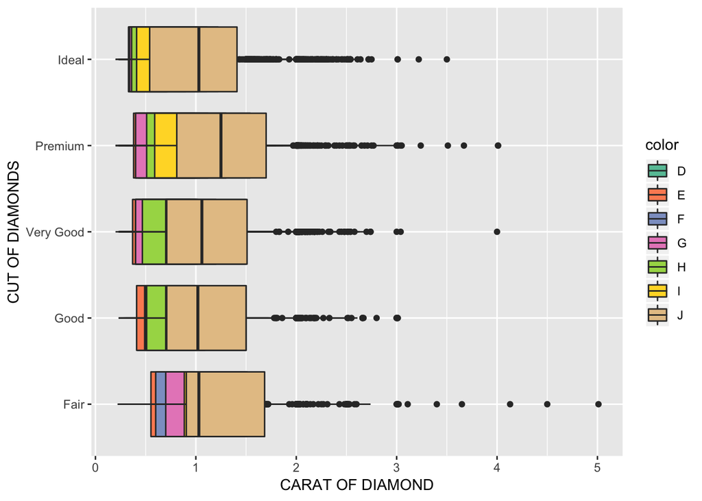

```r
data(diamonds)
ggplot(data = diamonds) +
  geom_boxplot(mapping = aes(x = cut, y = carat, fill = color),position = "identity")+
  scale_fill_brewer(palette="Set2")+
  labs(x = "CUT OF DIAMONDS", y = "CARAT OF DIAMOND")+
  coord_flip()
```

## Data munging and wrangling

#### 1. Is this data “tidy”? If yes, leave it alone and go to the next problem. If no, make it tidy.

The data in `table2` is not “tidy” as it has cases of TB and country population as different entries.  
It is better to have a row for each country for each year as in modified data below.

```r
data(table2)
fixed_table2 <- table2%>% spread(key = type,value = count)
head(fixed_table2)
```

```
## # A tibble: 6 x 4
##   country      year  cases population
##   <chr>       <int>  <int>      <int>
## 1 Afghanistan  1999    745   19987071
## 2 Afghanistan  2000   2666   20595360
## 3 Brazil       1999  37737  172006362
## 4 Brazil       2000  80488  174504898
## 5 China        1999 212258 1272915272
## 6 China        2000 213766 1280428583
```

#### 2. Create a new column in the diamonds data set called price_per_carat that shows the price of each diamond per carat (hint: divide). Only show me the code, not the output.

```r
data(diamonds)
new_diamonds = diamonds%>%mutate("price_per_carat" = price/carat)
```

```r
diamonds%>%group_by(cut) %>%summarise("high_price_small_carat_num"=sum(carat<1.5&price>1000),"proportion" = sum(carat<1.5&price>1000)/n(), "N" = n())
```

```
## # A tibble: 5 x 4
##   cut       high_price_small_carat_num proportion     N
##   <ord>                          <int>      <dbl> <int>
## 1 Fair                            1174      0.729  1610
## 2 Good                            3153      0.643  4906
## 3 Very Good                       7462      0.618 12082
## 4 Premium                         8348      0.605 13791
## 5 Ideal                          13044      0.605 21551
```

## EDA

#### Take a look at the txhousing data set that is included with the ggplot2 package and answer these questions:

```r
data(txhousing)
```

- During what time period is this data from?  
  A: 2000-2015

```r
max(txhousing$year)
```

```
## [1] 2015
```

```r
min(txhousing$year)
```

```
## [1] 2000
```

- How many cities are represented?  
  A: 46

```r
txhousing%>%count(city)%>%summarise(n=n())
```

```
## # A tibble: 1 x 1
##       n
##   <int>
## 1    46
```

- Which city, month and year had the highest number of sales?  
  A: Houston had max total sales. June was the month with most sales. 2006 was the year with most sales.

```r
txhousing%>%count(city,wt = sales)%>%arrange(desc(n))
```

```
## # A tibble: 46 x 2
##    city                    n
##    <chr>               <dbl>
##  1 Houston           1043999
##  2 Dallas             816122
##  3 Austin             373381
##  4 San Antonio        322097
##  5 Collin County      202892
##  6 Fort Bend          153088
##  7 Fort Worth         144791
##  8 NE Tarrant County  128007
##  9 Denton County      117405
## 10 Montgomery County  104589
## # … with 36 more rows
```

```r
txhousing%>%count(month,wt = sales)%>%arrange(desc(n))
```

```
## # A tibble: 12 x 2
##    month      n
##    <int>  <dbl>
##  1     6 472732
##  2     7 454096
##  3     5 448968
##  4     8 417246
##  5     4 397332
##  6     3 386909
##  7     9 341654
##  8    10 332003
##  9    12 324843
## 10    11 297085
## 11     2 296410
## 12     1 245924
```

```r
txhousing%>%count(year,wt = sales)%>%arrange(desc(n))
```

```
## # A tibble: 16 x 2
##     year      n
##    <int>  <dbl>
##  1  2006 347733
##  2  2014 345720
##  3  2013 335094
##  4  2007 327701
##  5  2005 316046
##  6  2012 287052
##  7  2004 283999
##  8  2008 276664
##  9  2009 255254
## 10  2003 253909
## 11  2011 246356
## 12  2010 243014
## 13  2002 234600
## 14  2001 231453
## 15  2000 222483
## 16  2015 208124
```

- What kind of relationship do you think exists between the number of listings and the number of sales? Check your assumption and show your work.  
  A:My guess is the more listing there are there will be more sales. Maybe up to a point where there some extreme case where the mount of listing is stable but sales drop (no one is buying and listings stay up). After plotting the relations between the values it seems there is a general tendency to have more sales when there are more listings. this doesn’t say much since it is more then likely a result of city size. This data does not contain city size or population so I won’t try to factor that in.

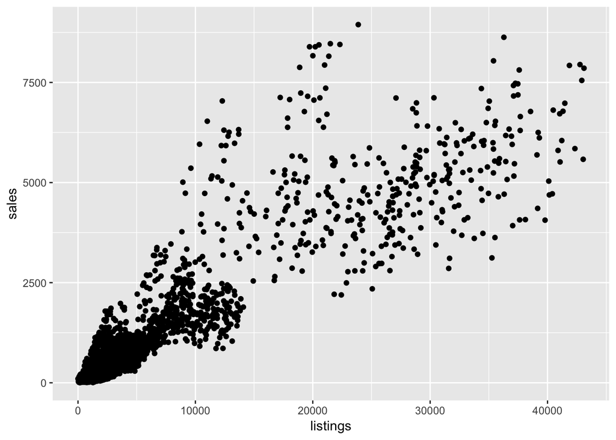

```r
ggplot(txhousing,aes(x= listings, y = sales))+geom_point()
```

- What proportion of sales is missing for each city?

```r
txhousing%>%count(city,wt = is.na(sales)/n())%>%arrange(desc(n))
```

```
## # A tibble: 46 x 2
##    city                    n
##    <chr>               <dbl>
##  1 South Padre Island 0.620
##  2 Kerrville          0.556
##  3 Midland            0.401
##  4 Odessa             0.385
##  5 San Marcos         0.246
##  6 Laredo             0.193
##  7 Harlingen          0.134
##  8 Waco               0.102
##  9 Texarkana          0.0909
## 10 Brazoria County    0.0749
## # … with 36 more rows
```

- Looking at only the cities and months with greater than 500 sales:
  - Are the distributions of the median sales price (column name median), when grouped by city, different? The same? Show your work.  
    A: not sure about the meaning of this…. I will skip :(
  - Any cities that stand out that you’d want to investigate further?  
    A: I think it could be interesting to look at low inventory time cities to understand why sales are so fast in them.
  - Why might we want to filter out all cities and months with sales less than 500?  
    A: 500 is a large enough number to figure statistical trends. With lower numbers we may get more influence of extreme cases.

```r
big_sales<-txhousing%>%filter(sales>500)
big_sales%>%arrange(inventory)
```

```
## # A tibble: 1,883 x 9
##    city           year month sales   volume median listings inventory  date
##    <chr>         <int> <int> <dbl>    <dbl>  <dbl>    <dbl>     <dbl> <dbl>
##  1 Collin County  2014    12  1235   3.81e8 272200     1788       1.3 2015.
##  2 Collin County  2015     1   776   2.42e8 268000     1780       1.3 2015
##  3 Arlington      2015     5   526   1.13e8 179100      614       1.4 2015.
##  4 Collin County  2013    12  1126   3.21e8 251100     1892       1.4 2014.
##  5 Collin County  2015     2   938   3.01e8 283400     1817       1.4 2015.
##  6 Collin County  2015     3  1258   4.13e8 285800     1811       1.4 2015.
##  7 Denton County  2015     2   592   1.47e8 212500     1114       1.4 2015.
##  8 NE Tarrant C…  2014    12   717   1.89e8 201300     1079       1.4 2015.
##  9 NE Tarrant C…  2015     2   549   1.50e8 203400     1080       1.4 2015.
## 10 NE Tarrant C…  2015     3   796   2.25e8 213300     1122       1.4 2015.
## # … with 1,873 more rows
```